# Powercreep in Fire Emblem Heroes

Jeffrey Cai

## Introduction

Fire Emblem Heroes (FEH) is a tactical role-playing game for mobile devices. However, it is also a gacha game. The term "gacha" comes from gachapon, toy vending machines in Japan. In video games, this effectively translates into a gambling system involving microtransactions. The gacha in FEH consists of summoning various characters, or Heroes, that you can use to play the game. The profits generated by FEH come from people spending real money in exchange for a virtual currency (in FEH, these are orbs) that can be used to summon for more Heroes. But after people summon all the Heroes they want, they'd have no reason to keep summoning, and thus no reason to spend. That's where powercreep comes in. When the new Heroes that come out are stronger than previous Heroes, people will want to summon again. And FEH continues to profit. While powercreep is important for profits, it also has negative consequences as well. Old Heroes become obsolete and harder to use. Players become more frustrated and some may quit as their favorite Heroes become comparatively worse and worse. It is generally acknowledged that FEH has pretty extreme powercreep, and here we will try to analyze just how bad it is.

## Data Collection and Tidying

We will be using various tables provided by the [Fire Emblem Heroes Fandom Wiki](https://feheroes.fandom.com/wiki/Main_Page). We will use the following:

- Heroes
  - [List of Heroes](https://feheroes.fandom.com/wiki/List_of_Heroes)
  - [Level 40 Stats](https://feheroes.fandom.com/wiki/Level_40_stats_table)
  - [Hero Skills](https://feheroes.fandom.com/wiki/Hero_skills_table)
- Skills
  - Weapons
  - Passives

To collect the data from the wiki, we will use the [Requests](https://docs.python-requests.org/en/master/) library to get the HTML source code. We'll then use [Beautiful Soup](https://www.crummy.com/software/BeautifulSoup/bs4/doc/) to parse the HTML. Finally, we'll read the parsed HTML into a [Pandas](https://pandas.pydata.org/pandas-docs/stable/index.html) DataFrame.

First, we'll import the necessary libraries.

```python
!pip install lxml
from bs4 import BeautifulSoup as bs
from sklearn import linear_model, tree
import requests, pandas as pd, numpy as np, matplotlib.pyplot as plt, statsmodels.api as sm, datetime
```

Then, we'll collect the data. Since I'm scraping many tables from different pages of the same site, I made a function for convenience. Given the site and some other parameters, it'll return a Pandas DataFrame.

```python
# getDF, short for getDataFrame
# parameters:
#   url: the site to load
#   idx: the index of the table on the webpage, useful when there are multiple tables
#   imgText: if True, it will convert all images in the table into their alt text

def getDF(url, idx=0, imgTxt=False):
    # get the HTML of the site using Requests
    r = requests.get(url)
    # Beautiful Soup gives us a nice parse tree from the HTML
    root = bs(r.content)
    # find all of the table objects and get the one of the specified index
    tbl = root.find_all('table')[idx]

    if imgTxt:
        # within the table, iterate over all of the images
        for img in tbl.find_all('img'):
            # create a text tag with the alt text of the image, and replace the image with the text tag
            new_tag = bs().new_tag('p')
            new_tag.string = img['alt']
            tbl.img.replace_with(new_tag)

    return pd.read_html(tbl.prettify())[0]
```

Data collection for Heroes

```python
# get the DataFrame for the list of Heroes
hero_list = getDF('https://feheroes.fandom.com/wiki/List_of_Heroes', imgTxt=True)
# some initial data tidying (dropping unneeded columns, renaming others)
hero_list = hero_list.drop(columns=['Unnamed: 0', 'Appears in', 'Entry', 'Rarities'])
hero_list = hero_list.rename(columns={'Move': 'Move type', 'Weapon': 'Weapon type'})

# the other DataFrames follow, each with their own tidying
lv_40_stats = getDF('https://feheroes.fandom.com/wiki/Level_40_stats_table')
lv_40_stats = lv_40_stats.drop(columns=['Unnamed: 0', 'Entry', 'Move', 'Weapon'])

hero_skills = getDF('https://feheroes.fandom.com/wiki/Hero_skills_table')
hero_skills = hero_skills.drop(columns=['Unnamed: 0', 'Move', 'Weapon'])
hero_skills = hero_skills.rename(columns={'Weapon.1': 'Weapon'})

# merge all of the above DataFrames on the Hero column
# join and concat perform similarly and can operate on multiple tables in one function call
# with merge, I can be sure that each row is for one specific Hero and no data is mixed up between tables
hero_list = hero_list.merge(lv_40_stats, how='left', on='Hero') \
                     .merge(hero_skills, how='left', on='Hero')
```

When merging the hero_list with other DataFrames, I set the 'how' parameter to 'left'. This was because the most recent Heroes were not yet added to all of the tables (at the time of writing this). The data is on their individual pages though. We could scrape those pages and collect the missing data, but here I just added them manually instead since there's only 5 of them.

```python
for i in [122, 138, 429, 430]:
    hero_list.loc[i, 'Release date'] = '2021-05-07'

cols = ['Weapon', 'Assist', 'Special', 'Passive A', 'Passive B', 'Passive C']
hero_list.loc[122, cols] = ['Vengeful Lance', '—', 'Glimmer', 'Atk/Spd Solo 4', 'Murderous Lion', 'Odd Tempest 3']
hero_list.loc[138, cols] = ['Twin-Crest Power', '—', 'Bonfire', 'Atk/Def Ideal 4', 'Armored Wall', 'Armored Stride 3']
hero_list.loc[429, cols] = ['Axe of Despair', '—', 'Glimmer', 'Atk/Def Solo 4', 'Dive-Bomb 3', 'Atk/Def Menace']
hero_list.loc[430, cols] = ['Tome of Despair', '—', 'Iceberg', 'Atk/Res Solo 4', 'Sabotage Def 3', 'Atk/Res Menace']
hero_list.loc[476, cols] = ['Bereft Lance', '—', 'Ignis', '—', 'Vantage 3', 'Rouse Atk/Def 3']
```

Finally, we need to make sure our data is of the appropriate type.

```python
hero_list['Release date'] = pd.to_datetime(hero_list['Release date'])
```

Data collection for Skills

```python
# this takes advantage of the idx parameter using a list comprehension
# read all of the weapon tables and put them into a list of DataFrames
weapons = [getDF('https://feheroes.fandom.com/wiki/Weapons', i) for i in range(12)]
for i in range(12):
    if 'Sprite' in weapons[i].columns:
        weapons[i] = weapons[i].drop(columns=['Sprite'])
# concatenate all of the tables into one
weapons = pd.concat(weapons)

# with Passives, there are multiple tables to read again
passives = [getDF('https://feheroes.fandom.com/wiki/Passives', i) for i in range(1, 4)]
for i in range(3):
    passives[i] = passives[i].drop(columns=['Icon'])
    # add a column to each DataFrame specifying the skill type
    passives[i]['Type'] = ['A', 'B', 'C'][i]
    passives[i] = passives[i][['Name', 'Type', 'Description', 'SP', 'Is exclusive']]
passives = pd.concat(passives)
```

Here are the first few rows of each DataFrame.

```python
hero_list.head()
```

|  | Hero | Move type | Weapon type | Release date | HP | Atk | Spd | Def | Res | Total | Weapon | Assist | Special | Passive A | Passive B | Passive C |
| --- | --- | --- | --- | --- | --- | --- | --- | --- | --- | --- | --- | --- | --- | --- | --- | --- |
| 0 | Abel: The Panther | Cavalry | Blue Lance | 2017-02-02 | 39 | 33 | 32 | 25 | 25 | 154 | Brave Lance+ Panther Lance | — | Aegis | HP +5 | Swordbreaker 3 | — |
| 1 | Alfonse: Askran Duo | Infantry | Blue Tome | 2020-01-01 | 41 | 38 | 17 | 35 | 30 | 161 | Imbued Koma | — | Open the Future | Close Counter | Special Spiral 3 | Def/Res Oath 3 |
| 2 | Alfonse: Prince of Askr | Infantry | Red Sword | 2017-02-02 | 43 | 35 | 25 | 32 | 22 | 157 | Fólkvangr | — | Sol | Death Blow 3 | — | Spur Atk 3 |
| 3 | Alfonse: Spring Prince | Cavalry | Green Axe | 2018-03-22 | 41 | 35 | 33 | 30 | 18 | 157 | Giant Spoon+ | — | Noontime | Sturdy Blow 2 | — | Def Smoke 3 |
| 4 | Alfonse: Uplifting Love | Armored | Green Tome | 2021-02-05 | 43 | 38 | 25 | 37 | 31 | 174 | Amity Blooms+ | — | Moonbow | Def/Res Form 3 | Bold Fighter 3 | — |

```python
weapons.head()
```

|  | Weapon | Might | Range | Description | SP | Exclusive |
| --- | --- | --- | --- | --- | --- | --- |
| 0 | Alondite | 16 | 1 | Unit can counterattack regardless of foe's range. | 400 | Yes |
| 1 | Amatsu | 16 | 1 | Accelerates Special trigger (cooldown count-1)... | 400 | Yes |
| 2 | Amiti | 11 | 1 | Inflicts Spd-2. If unit initiates combat, unit... | 400 | Yes |
| 3 | Arden's Blade | 10 | 1 | Inflicts Spd-5. Unit attacks twice. (Even if ... | 400 | Yes |
| 4 | Ardent Durandal | 16 | 1 | Grants Atk+3. At start of turn, grants 【Bonus ... | 400 | Yes |

```python
passives.head()
```

|  | Name | Type | Description | SP | Is exclusive |
| --- | --- | --- | --- | --- | --- |
| 0 | AR-D Atk/Def 1 | A | If defending in Aether Raids, grants Atk/Def+X... | 60 | No |
| 1 | AR-D Atk/Def 2 | A | If defending in Aether Raids, grants Atk/Def+X... | 120 | No |
| 2 | AR-D Atk/Def 3 | A | If defending in Aether Raids, grants Atk/Def+X... | 240 | No |
| 3 | AR-D Atk/Res 1 | A | If defending in Aether Raids, grants Atk/Res+X... | 60 | No |
| 4 | AR-D Atk/Res 2 | A | If defending in Aether Raids, grants Atk/Res+X... | 120 | No |

## Missing Data

There are 3 types of missing data to watch out for.

- Missing Completely At Random (MCAR) - The missing data is not due to any of the data.
- Missing At Random (MAR) - The missing data is due to some other data.
- Missing Not At Random (MNAR) - The missing data is due to the data itself.

Let's see what missing data we have to deal with.

```python
# isnull() tells us if a cell is missing data (typically seen as NaN)
# the first sum() sums the amount of cells with missing data in each column
# the second sum() sums those to get the amount of cells with missing data in the whole DataFrame
data = [hero_list, weapons, passives]
[df.isnull().sum().sum() for df in data]
```

```
[0, 41, 2]
```

We have 41 missing values for Weapons and 2 for Passives. Let's take a closer look at each.

```python
weapons.isnull().sum()
```

```
Weapon          0
Might           0
Range           0
Description    41
SP              0
Exclusive       0
dtype: int64
```

```python
print(list(weapons[weapons['Description'].isnull()]['Weapon']))
```

[output not shown]

Those familiar with the game would recognize that these are just the basic weapons for each weapon type that have no additional effects. This isn't really missing data per se, since these weapons actually don't have descriptions. We can replace these with empty strings to more accurately represent the data.

```python
weapons = weapons.replace(np.nan, '')
```

```python
passives.isnull().sum()
```

```
Name            0
Type            0
Description     2
SP              0
Is exclusive    0
dtype: int64
```

```python
passives[passives['Description'].isnull()]
```

|  | Name | Type | Description | SP | Is exclusive |
| --- | --- | --- | --- | --- | --- |
| 149 | Even Follow-Up 1 | B | NaN | 60 | No |
| 139 | Even Tempest 1 | C | NaN | 60 | No |

The two skills with missing descriptions are Even Follow-Up 1 and Even Tempest 1. There doesn't seem to be any particular reason why these skills in particular are missing descriptions. Although there are many similarities between these 2 skills, there are many other skills that share those similarities that do not have missing descriptions. Considering that these are the only 2 skills with missing descriptions out of all 1125 skills in the table, the sample size is too small to effectively determine what type of missing data this is. It could very well be Missing Completely At Random (MCAR). The wiki editors may have just missed these by chance. The case could be made for Missing At Random (MAR) if the data was missing because they were Level 1 skills, whereas people only care about the Level 3+ versions skills. If the descriptions themselves were the cause for the missing data, it would be Missing Not At Random (MNAR).

Missing data can be fairly tricky to understand, especially with its unhelpful acronyms. This [INWT blog post](https://www.inwt-statistics.com/read-blog/understanding-and-handling-missing-data.html) has some good examples and visuals that may help.

## Exploratory Data Analysis

Let's plot some data and see if we find any patterns.

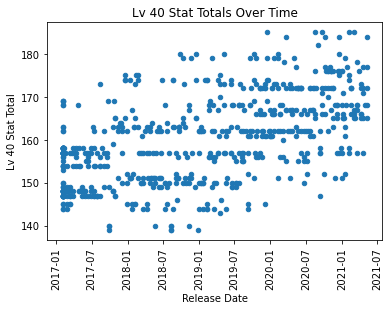

```python
hero_list.plot.scatter('Release date', 'Total', title='Lv 40 Stat Totals Over Time',
                       xlabel='Release Date', ylabel='Lv 40 Stat Total', rot=90);
```

First, I simply made a scatterplot of Lv 40 Stat Totals v.s. Release Date. There does appear to be an upward trend, indicating that the variables are positively correlated.

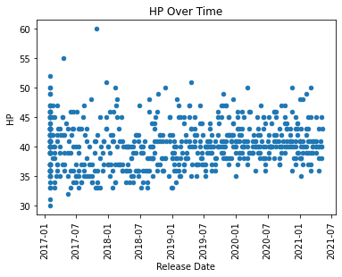

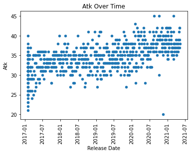

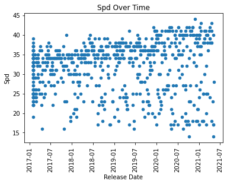

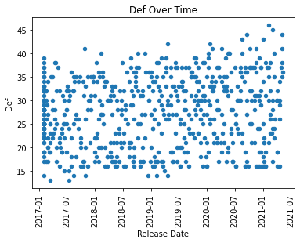

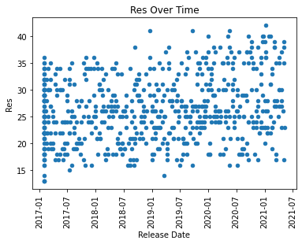

```python
stats = hero_list.columns[4:9]
for stat in stats:
    hero_list.plot.scatter('Release date', stat, title=stat + ' Over Time', xlabel='Release Date', rot=90);
```

Next, I made scatterplots for the values of each of the 5 stats over time. There are some interesting trends to observe here. HP appears to converge over time, seemingly towards 40 HP. Atk appears to increase over time. Spd is interesting. There is a trend of increasing points at the top, but there is a wide range of points that fall below, with the lowest Spd decreasing. Def and Res are similar. Both maintain a high variance, but the upper bound does increase over time.

These trends do make sense considering the game's mechanics. For the offensive stats, more Atk is almost always better than less Atk. It's only natural that Atk keeps increasing. Spd is different. When a Hero has 5 or more Spd than their opponent, they can perform a follow-up attack. Due to this, Spd is effectively only useful if you can perform follow-up attacks against most foes. This explains the increasing highest Spd at the top. However, if a Hero has middling Spd, it's "wasted stats." Slow Heroes don't care about Spd, and could benefit from an increase to their other stats instead, hence the decreasing lowest Spd. For the defensive stats, HP loses value comparatively the more hits you take. More Def and Res help more after more fights. Heroes appear to be given enough HP to not be one-shot, but they aren't being given more HP since the Def and Res become relatively better.

For further analysis, I want to see if there are any patterns based on particular columns. I made another fairly tuned function, this time to help facilitate the plotting.

```python
# multiPlot, allows for plotting with a particular column to determine the color of the points
# parameters:
#   col: the column to distinguish
#   labels: the unique values of the column
#   colors: the colors corresponding to the labels
#   title
#   rot: rotation of the x labels
#   df: the DataFrame
#   x: column name to plot as x
#   y: column name to plot as y
#   xlabel
#   ylabel

def multiPlot(col, labels, colors, title, rot,
              df=hero_list, x='Release date', y='Total', xlabel='Release Date', ylabel='Lv 40 Stat Total'):
    ax = df[df[col] == labels[0]].plot.scatter(x, y, color=colors[0], label=labels[0])
    j = len(labels) - 1
    for i in range(1, j):
        df[df[col] == labels[i]].plot.scatter(x, y, color=colors[i], label=labels[i], ax=ax)
    df[df[col] == labels[j]].plot.scatter(x, y, color=colors[j], label=labels[j], ax=ax,
                                          title=title, xlabel=xlabel, ylabel=ylabel, rot=rot)
```

For our first application of this, let's look at the stats over time as they relate to Movement type.

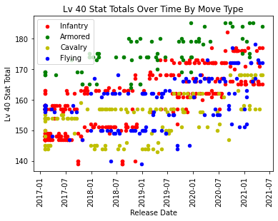

```python
moveTypes = ['Infantry', 'Armored', 'Cavalry', 'Flying']
moveColors = ['r', 'g', 'y', 'b']
multiPlot('Move type', moveTypes, moveColors, 'Lv 40 Stat Totals Over Time By Move Type', 90)
```

There are some patterns we can see. To the surprise of no one, Armored Heroes are consistently at the top. Infantry, Cavalry, and Flying are below, with Infantry slightly higher than the other two.

Next, we'll look at the stats over time as they relate to Color.

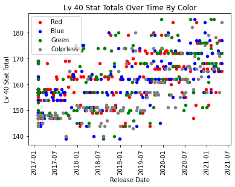

```python
# we need to get a Hero's color from their weapon type
hero_list['Color'] = [s.split()[0] for s in hero_list['Weapon type']]
colorTypes = ['Red', 'Blue', 'Green', 'Colorless']
weaponColors = ['r', 'b', 'g', 'gray']
multiPlot('Color', colorTypes, weaponColors, 'Lv 40 Stat Totals Over Time By Color', 90)
```

There are no obvious trends in the data when distinguishing by color.

Now we'll look at the stats over time as they relate to Weapon Range.

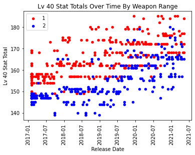

```python
# to get Range, we need to find the Hero's weapon in the weapons DataFrame
hero_list['Range'] = [int(np.unwrap(weapons[weapons['Weapon'] == s.split('  ')[0]]['Range'])[0]) for s in hero_list['Weapon']]
multiPlot('Range', [1, 2], ['r', 'b'], 'Lv 40 Stat Totals Over Time By Weapon Range', 90)
```

Here, we can see that 1 Range (Melee) Heroes consistently have higher stats than 2 Range (Ranged) Heroes.

Stat powercreep is not the only form of powercreep of course. Skills also exhibit powercreep as well. Let's look at skill descriptions for weapons first.

```python
weaponDate = []

# find the earliest date for the weapon from the hero_list DataFrame
for weapon in weapons['Weapon']:
    dates = hero_list[hero_list['Weapon'] == weapon]['Release date']
    weaponDate.append(np.nan if len(dates) == 0 else min(dates))

weapons['Date'] = weaponDate
weapons['Description length'] = weapons['Description'].str.len()
weapons = weapons.dropna()
```

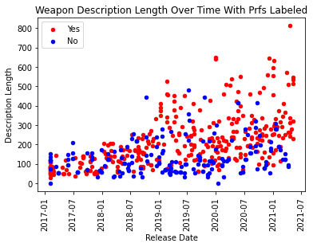

```python
multiPlot('Exclusive', ['Yes', 'No'], ['r', 'b'],
          'Weapon Description Length Over Time With Prfs Labeled', 90, df=weapons, x='Date', y='Description length',
          ylabel='Description Length')
```

While character length of the description isn't the best way to measure skill powercreep, it's a really simple metric. Longer descriptions imply more complex skill effects, which could be used as indicator of skill powercreep. Here, we can see that weapon description length increases significantly starting around the start of 2019. Furthermore, the weapons with the longest descriptions are predominantly Prfs (a Fire Emblem term meaning a weapon can only be used by a specific character, exclusive).

Let's look at passive skills next.

```python
passiveDate = []

for idx, row in passives.iterrows():
    dates = hero_list[hero_list['Passive ' + row['Type']] == row['Name']]['Release date']
    passiveDate.append(np.nan if len(dates) == 0 else min(dates))

passives['Date'] = passiveDate
passives['Description length'] = passives['Description'].str.len()
passives = passives.dropna()
```

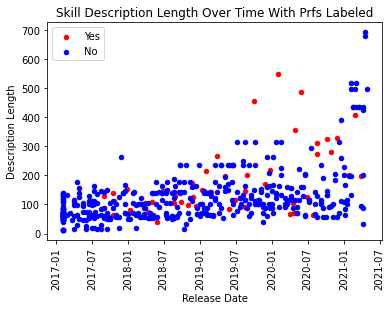

```python
multiPlot('Is exclusive', ['Yes', 'No'], ['r', 'b'],
          'Skill Description Length Over Time With Prfs Labeled', 90, df=passives, x='Date', y='Description length',
          ylabel='Description Length')
```

Here, the descriptions don't become absurdly long until late 2019, and inheritable (non-exclusive) skills surpass the Prf (exclusive) skills in 2021.

As stated before, description length is a simple metric, and one that doesn't even analyze the contents of the descriptions. If you wanted to do a language analysis, you should look into [nltk](https://www.nltk.org/).

## Hypothesis Testing

Now let's do some hypothesis testing. In hypothesis testing, you have the null hypothesis ($H_0$) that is assumed to be true. You then have an alternative hypothesis ($H_a$) that you wish to test. You then conduct a test of significance to determine whether or not to reject $H_0$ in favor of $H_a$. We will use [statsmodels](https://www.statsmodels.org/stable/index.html) to do the statistics work for us.

First, we'll test the null hypothesis that there is no (linear) relation between Release date and Lv 40 stat total, with the alternative hypothesis that there is. We can use statsmodels to calculate an [Ordinary Least Squares (OLS)](https://www.statsmodels.org/stable/generated/statsmodels.regression.linear_model.OLS.html) linear regression model as well as the relevant test statistics.

```python
# statsmodels doesn't like DateTimes so we need to create a new column with a form of the date that statsmodels can work with
hero_list['Days'] = [t.days for t in list(hero_list['Release date'] - hero_list['Release date'].min())]
# add a constant so we can have a y-intercept
x = sm.add_constant(hero_list['Days'])
y = hero_list['Total']
ols = sm.OLS(y, x).fit()
ols.summary()
```

OLS Regression Results

| Dep. Variable: | Total | R-squared: | 0.316 |
| --- | --- | --- | --- |
| Model: | OLS | Adj. R-squared: | 0.314 |
| Method: | Least Squares | F-statistic: | 302.9 |
| Date: | Mon, 17 May 2021 | Prob (F-statistic): | 4.54e-56 |
| Time: | 12:00:00 | Log-Likelihood: | -2335.2 |
| No. Observations: | 659 | AIC: | 4674. |
| Df Residuals: | 657 | BIC: | 4683. |
| Df Model: | 1 |  |  |
| Covariance Type: | nonrobust |  |  |

|  | coef | std err | t | P>\|t\| | [0.025 | 0.975] |
| --- | --- | --- | --- | --- | --- | --- |
| const | 152.1689 | 0.558 | 272.721 | 0.000 | 151.073 | 153.264 |
| Days | 0.0113 | 0.001 | 17.403 | 0.000 | 0.010 | 0.013 |

| Omnibus: | 3.390 | Durbin-Watson: | 1.485 |
| --- | --- | --- | --- |
| Prob(Omnibus): | 0.184 | Jarque-Bera (JB): | 2.957 |
| Skew: | 0.081 | Prob(JB): | 0.228 |
| Kurtosis: | 2.714 | Cond. No. | 1.46e+03 |

Notes:  
[1] Standard Errors assume that the covariance matrix of the errors is correctly specified.  
[2] The condition number is large, 1.46e+03. This might indicate that there are  
strong multicollinearity or other numerical problems.

The slope generated is 0.0113 with a *t* value of 17.403 and a *p*-value of 0. We can reject $H_0$. However, as the summary informs us, there may be multicollinearity or other numerical problems. There are likely interactions between variables such as Movement type, Weapon range, and Release date. Additionally, the data is not truly linear. There are many constant lines in the data since stat powercreep is not incremental. Rather, stat powercreep appears to occur in discrete time intervals. All of these constant lines cumulatively form something that is seemingly linear on average, which is why I still thought the linear model was worth generating. But, since the data isn't truly linear, the model's predictive power will be terrible. The slope is useful in terms of broad averages, but not otherwise.

```python
ols.params[1] * 365
```

```
4.134419023500079
```

The slope of 0.0113 is small, but it is per day. It tells us that on average, Lv 40 stat totals increase by approximately 4 per year.

Next, we'll test the null hypothesis that there is no (linear) relation between Release date and Weapon Description length, with the alternative hypothesis that there is.

```python
weapons['Days'] = [t.days for t in list(weapons['Date'] - weapons['Date'].min())]
x = sm.add_constant(weapons['Days'])
y = weapons['Description length']
ols = sm.OLS(y, x).fit()
ols.summary()
```

OLS Regression Results

| Dep. Variable: | Description length | R-squared: | 0.242 |
| --- | --- | --- | --- |
| Model: | OLS | Adj. R-squared: | 0.241 |
| Method: | Least Squares | F-statistic: | 162.9 |
| Date: | Mon, 17 May 2021 | Prob (F-statistic): | 1.46e-32 |
| Time: | 12:00:00 | Log-Likelihood: | -3140.0 |
| No. Observations: | 512 | AIC: | 6284. |
| Df Residuals: | 510 | BIC: | 6293. |
| Df Model: | 1 |  |  |
| Covariance Type: | nonrobust |  |  |

|  | coef | std err | t | P>\|t\| | [0.025 | 0.975] |
| --- | --- | --- | --- | --- | --- | --- |
| const | 70.7544 | 10.161 | 6.963 | 0.000 | 50.791 | 90.717 |
| Days | 0.1390 | 0.011 | 12.762 | 0.000 | 0.118 | 0.160 |

| Omnibus: | 105.875 | Durbin-Watson: | 1.379 |
| --- | --- | --- | --- |
| Prob(Omnibus): | 0.000 | Jarque-Bera (JB): | 206.125 |
| Skew: | 1.150 | Prob(JB): | 1.74e-45 |
| Kurtosis: | 5.092 | Cond. No. | 1.92e+03 |

Notes:  
[1] Standard Errors assume that the covariance matrix of the errors is correctly specified.  
[2] The condition number is large, 1.92e+03. This might indicate that there are  
strong multicollinearity or other numerical problems.

The slope generated is 0.1390 with a *t* value of 12.762 and a *p*-value of 0. We can reject $H_0$. Once again, as the summary informs us, there may be multicollinearity or other numerical problems. This time, the data may be better fit by a higher power of regression, or perhaps exponential. The slope, while its specific value is less useful, does indicate the existence of some relation between Release date and Weapon Description length.

## Machine Learning

We can also generate linear models with machine learning. For this, we will use [scikit-learn](https://scikit-learn.org/stable/) and their [LinearRegression](https://scikit-learn.org/stable/modules/generated/sklearn.linear_model.LinearRegression.html) model.

```python
# use scikit-learn to fit a linear regression model
x = [[i] for i in hero_list['Days']]
y = [[i] for i in hero_list['Total']]
lm = linear_model.LinearRegression()
lm.fit(x, y)

# print the results
print('y = mx + b\nm = ', lm.coef_[0][0], '\nb = ', lm.intercept_[0])
```

```
y = mx + b
m =  0.011327175406849518
b =  152.1688813328255
```

As was stated in Hypothesis Testing, our data isn't really linear. Let's try a different regression model: the [DecisionTreeRegressor](https://scikit-learn.org/stable/modules/generated/sklearn.tree.DecisionTreeRegressor.html).

```python
# use scikit-learn to fit a decision tree regressor
dtr = tree.DecisionTreeRegressor(max_depth=2)
dtr.fit(x, y);
```

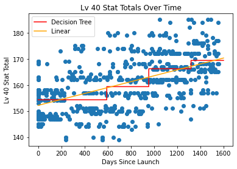

```python
# plot both models along with the data
x_test = np.arange(0., 1600., 0.01)[:, np.newaxis]
Y2 = dtr.predict(x_test)
YL = lm.predict(x_test)
plt.figure()
plt.scatter(x, y)
plt.plot(x_test, Y2, color='r', label='Decision Tree')
plt.plot(x_test, YL, color='orange', label='Linear')
plt.title('Lv 40 Stat Totals Over Time')
plt.xlabel('Days Since Launch')
plt.ylabel('Lv 40 Stat Total')
plt.legend()
plt.show()
```

Here, we can see the stat data again and both models that we fitted. Next, we can look at their inaccuracies. We'll do this by calculating and plotting the residuals. A residual is the difference between the observed and predicted values.

```python
# calculate the residuals of both models
hero_list['DT predict'] = dtr.predict(x)
hero_list['L predict'] = lm.predict(x)
hero_list['DT residual'] = hero_list['Total'] - hero_list['DT predict']
hero_list['L residual'] = hero_list['Total'] - hero_list['L predict']
```

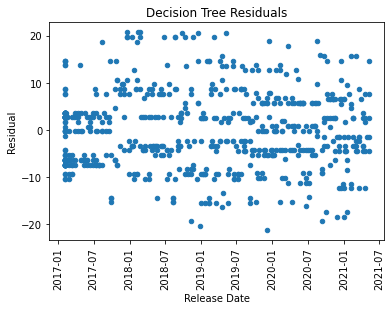

```python
hero_list.plot.scatter('Release date', 'DT residual', title='Decision Tree Residuals',
                       xlabel='Release Date', ylabel='Residual', rot=90);
```

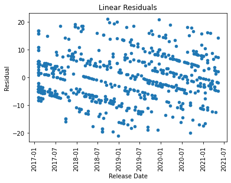

```python
hero_list.plot.scatter('Release date', 'L residual', title='Linear Residuals',
                       xlabel='Release Date', ylabel='Residual', rot=90);
```

Both residual plots resemble the original data in some way. The decision tree residuals appear rather normalized, and look like they could be the data points from a game without stat powercreep. The linear residuals have a downward slant, which comes from the original non-linear nature of the data.

## Conclusion

So how bad is FEH's powercreep? In terms of broad averages, each year results in an increase of ~4 stat points at Lv 40. So, broadly speaking, today's units have, on average, 16 more stat points than the unit's of the game's launch on 2/2/2017. Of course, the dstribution of those stats matters as well, and units now are pushing the Atk and Spd caps higher and higher, as well as Def and Res to a lesser extent. Additionally, skills are becoming increasingly complex, particularly Prf Weapons. If we did a deeper language analysis, perhaps we would have a better idea of how impactful skill effects are on powercreep.

Thank you for reading this and I hope you were able to learn a little about the data science pipeline in this project. The data science links throughout the tutorial are also below for your convenience.

- [Requests](https://docs.python-requests.org/en/master/)
- [Beautiful Soup](https://www.crummy.com/software/BeautifulSoup/bs4/doc/)
- [Pandas](https://pandas.pydata.org/pandas-docs/stable/index.html)
- [Missing data](https://www.inwt-statistics.com/read-blog/understanding-and-handling-missing-data.html)
- [Natural Language Toolkit](https://www.nltk.org/)
- [Statsmodels](https://www.statsmodels.org/stable/index.html)
- [OLS](https://www.statsmodels.org/stable/generated/statsmodels.regression.linear_model.OLS.html)
- [Scikit-learn](https://scikit-learn.org/stable/)
- [LinearRegression](https://scikit-learn.org/stable/modules/generated/sklearn.linear_model.LinearRegression.html)
- [DecisionTreeRegressor](https://scikit-learn.org/stable/modules/generated/sklearn.tree.DecisionTreeRegressor.html)